# Thalos Intelligence — Evidence Report

## Happy Path (Direct)

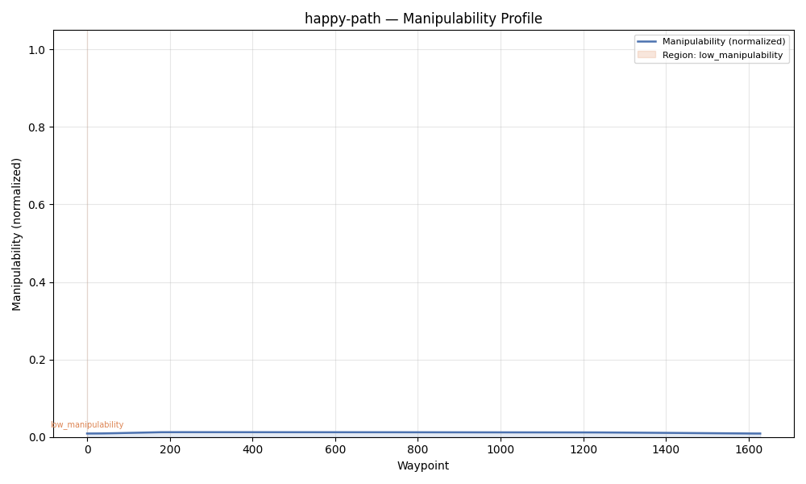

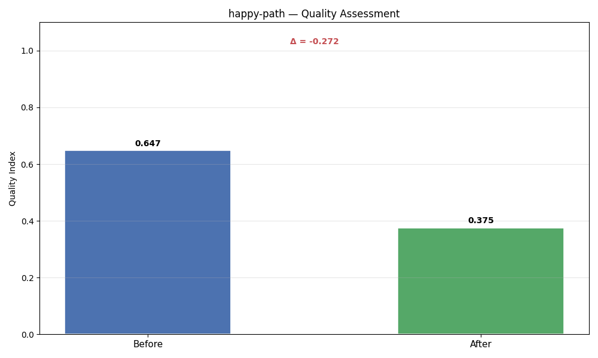

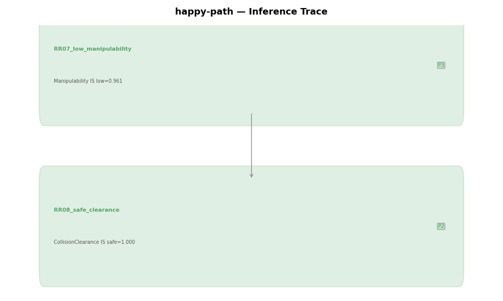

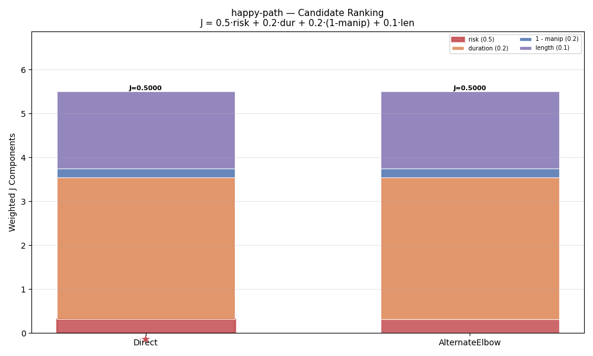

| Strategy | Risk | Duration | Manip | Length | J Score | Selected |
| --- | --- | --- | --- | --- | --- | --- |
| → Direct | 0.6250 | 16.158754 | 0.0116 | 17.5802 | **0.5000** | YES |
| AlternateElbow | 0.6250 | 16.158747 | 0.0116 | 17.5802 | **0.5000** |  |
| ε deadband | 1e-04 |  |  |  |  |  |
| Tie-break | first-in-order (stable sort) |  |  |  |  |  |
| Result: Selected: **Direct** |  |  |  |  |  |  |

## Multi-Object

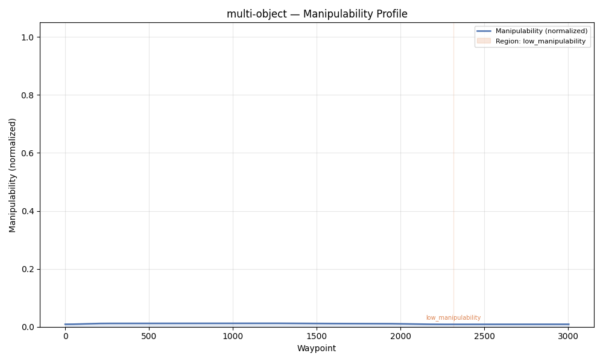

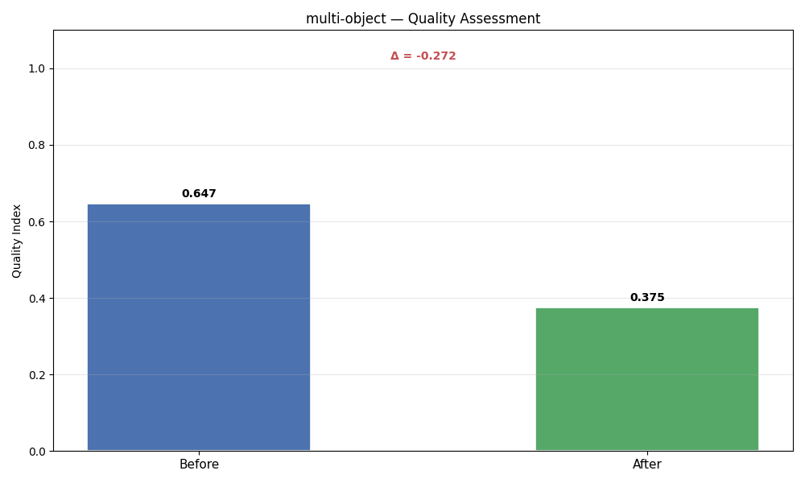

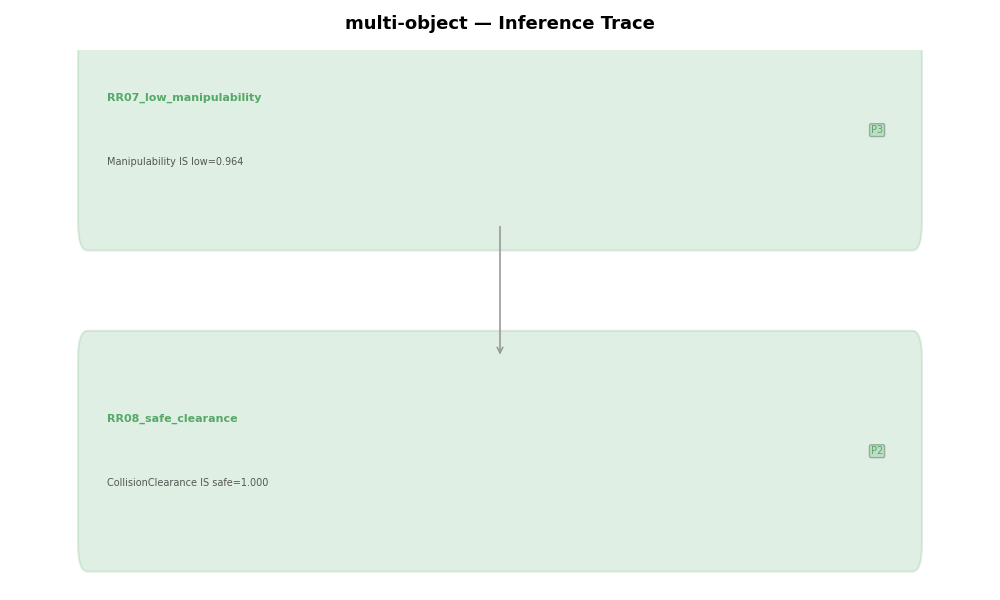

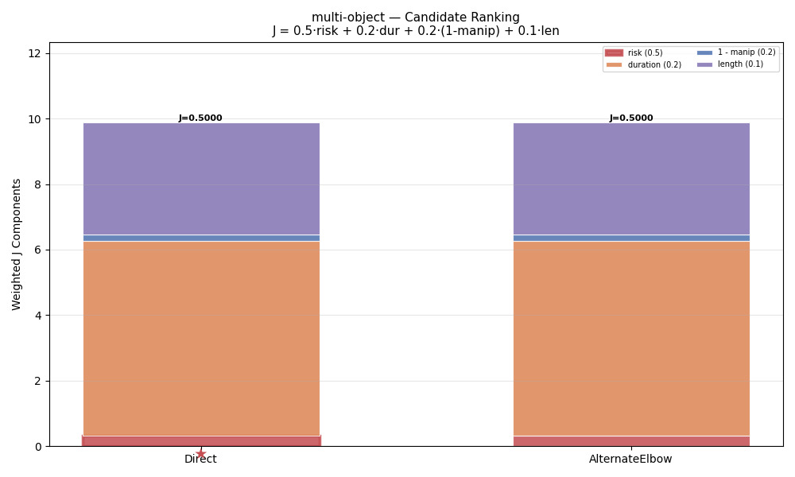

| Strategy | Risk | Duration | Manip | Length | J Score | Selected |
| --- | --- | --- | --- | --- | --- | --- |
| → Direct | 0.6250 | 29.801319 | 0.0108 | 34.0078 | **0.5000** | YES |
| AlternateElbow | 0.6250 | 29.801309 | 0.0108 | 34.0078 | **0.5000** |  |
| ε deadband | 1e-04 |  |  |  |  |  |
| Tie-break | first-in-order (stable sort) |  |  |  |  |  |
| Result: Selected: **Direct** |  |  |  |  |  |  |

## Repair Alternatives

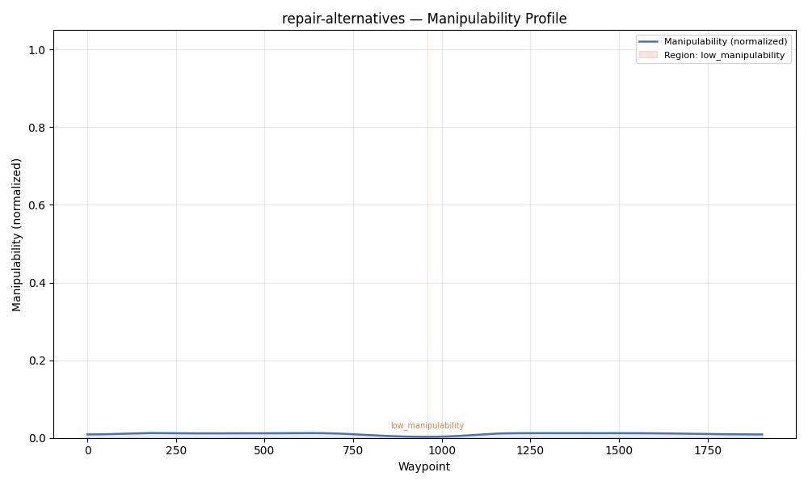

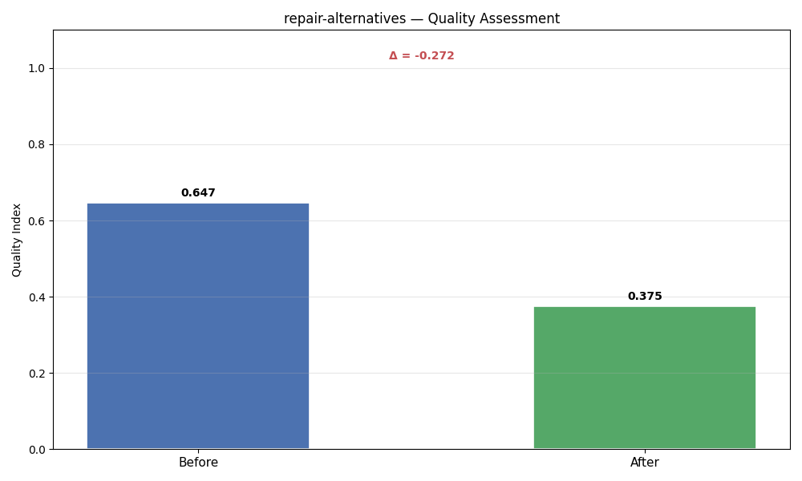

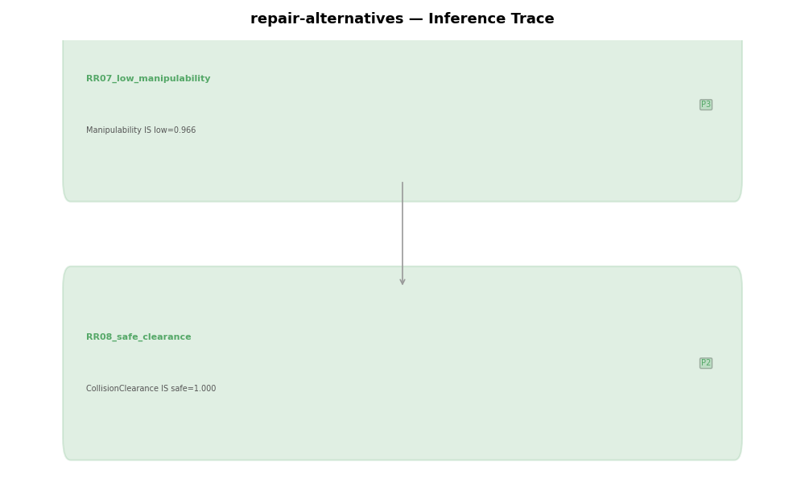

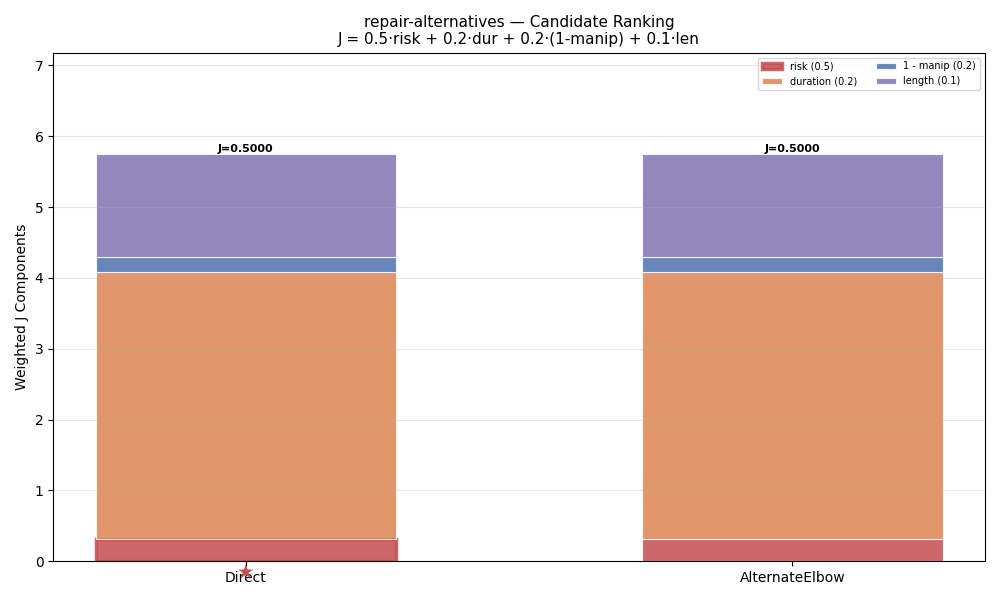

| Strategy | Risk | Duration | Manip | Length | J Score | Selected |
| --- | --- | --- | --- | --- | --- | --- |
| → Direct | 0.6250 | 18.893269 | 0.0102 | 14.5474 | **0.5000** | YES |
| AlternateElbow | 0.6250 | 18.893255 | 0.0102 | 14.5474 | **0.5000** |  |
| ε deadband | 1e-04 |  |  |  |  |  |
| Tie-break | first-in-order (stable sort) |  |  |  |  |  |
| Result: Selected: **Direct** |  |  |  |  |  |  |

## Safety Rejection

[figure not shown]

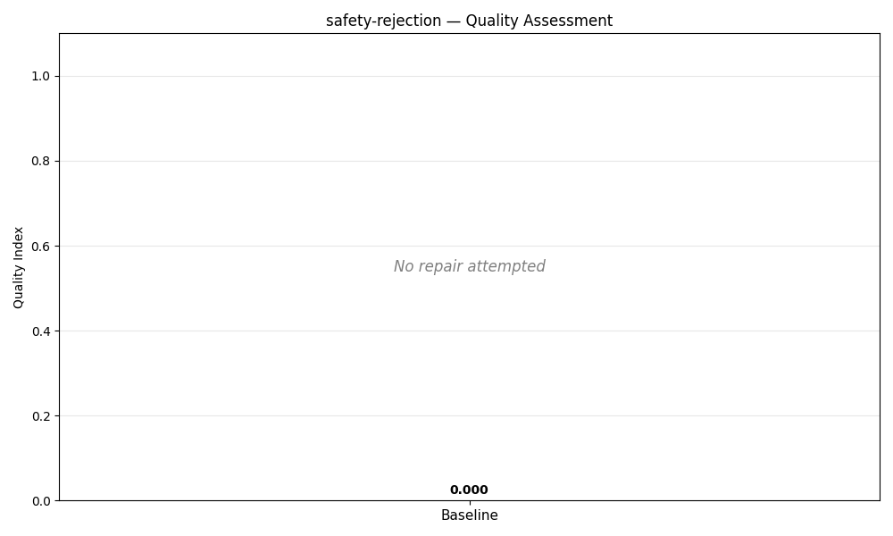

[figure not shown]

[figure not shown]

[output not shown]

## Cross-Scenario Summary

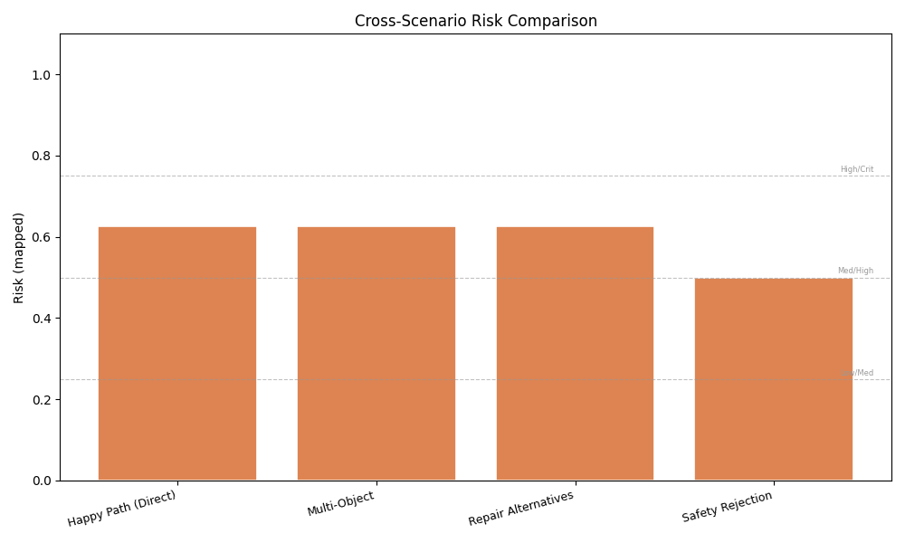

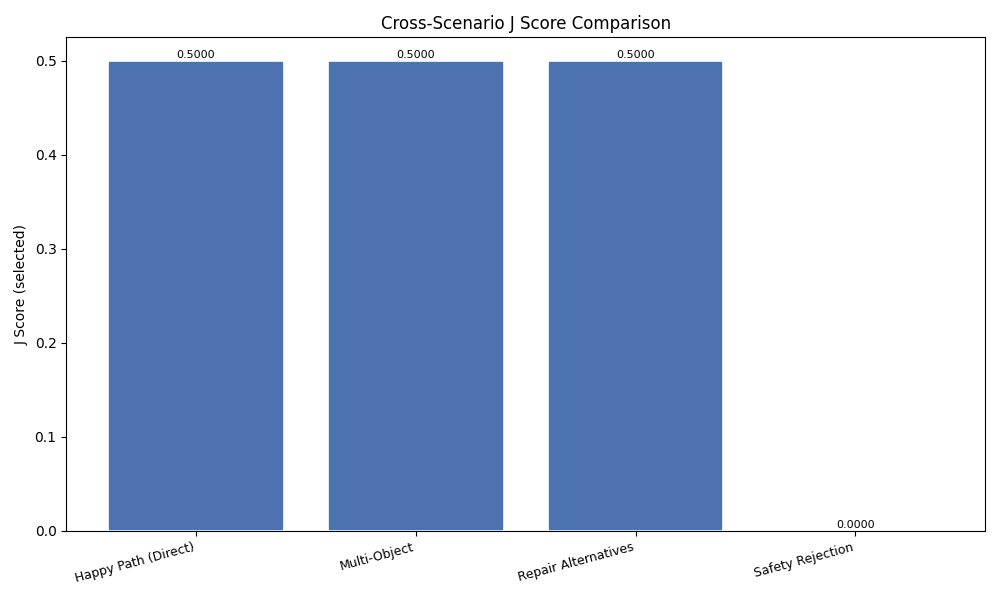

| Scenario | Verdict | Quality | Selected Strategy | J Score | Candidates | Repair |
| --- | --- | --- | --- | --- | --- | --- |
| Happy Path (Direct) | HIGH | 0.647 | Direct | 0.5000 | 2 | Yes |
| Multi-Object | HIGH | 0.647 | Direct | 0.5000 | 2 | Yes |
| Repair Alternatives | HIGH | 0.647 | Direct | 0.5000 | 2 | Yes |
| Safety Rejection | UNKNOWN | 0.000 | none | 0.0000 | 0 | No |

## Known Limitations

### Icebot — AlternateElbow Sub-ε Degeneration

On the `icebot` robot, the **AlternateElbow** realization is degenerate within the ε deadband (1×10⁻⁴). The joint-1 limit `[0, 2.0944]` constrains the configuration space such that the mirrored elbow cannot meaningfully diverge from the Direct solution.

**Risk floor R07** (~0.625) remains always active regardless of strategy, because the workspace geometry forces similar manipulability profiles across all realizations.

*The correct academic framing is **"alternatives surfaced / repair attempted"**, NOT "better path chosen". This is an academic strength: it demonstrates that Thalos Intelligence does not over-promise and reports real limitations of the configuration space honestly.*

The sub-ε degeneration is visible in the candidate ranking: all strategies achieve J scores within <10×ε of each other. The stable tie-break selects the first candidate in the original order (Direct), which is the deterministic and reproducible behavior.